# Naive Bayes Report

## 1. Motivation and Data Preprocessing

### Motivation

Naive Bates Classifier is a very popular and fast machine learning algorithm for a real-world problem. We are implementing a Naive Bayes algorithm that is able to predict the domain - one of Archaea, Bacteria, Eukaryota or Virus - from the abstract of research papers about proteins taken from the MEDLINE database.

The ultimate goal of this programming project is to come up with an implementation of a (possibly extended or modified) Naive Bayes algorithm, that achieves a high predictive accuracy on the test data. The algorithm will still be "Naive Bayes" in the sense that it makes the assumption that all attributes are conditionally independent of each other given the class.

### Data Preprocessing

The data set required the application of several process to improve the quality of it:

- As part of the data pre-processing we removed punctuation and transform the abstract class into a lowercase.
- We changed the names of the heading to upper class to avoid having double column with the word 'index','id', class' or 'abstract'.
- We excluded digits, common and redundant words (Stop Words) from the data set.
- We created a vocabulary of unique words from the 'abstract' class.
- We replace the 'abstract' class with the clean version of it.

## 2. Model improvements and implementation.

Naive Bayes Classifier calculate the probability of an input to be associate with a class instead of the label of the input. This algorithm is called naive because the model premises are hard to find in the real-world. It uses conditional probability to calculate a product of individual probabilities of its components. It assumes bsolute independence of features, given the class variable.

The standard Naive Bayes will probably yield comparably poor predictive accuracy. Therefore, we need to improve it in order to obtain good predictive accuracy. Some of the improvement we made are:

The training data set was imbalanced with mostly of the data classified as 'E':

```
    E    2144    0.54
    B    1602    0.40
    A     128    0.03
    V     126    0.03
```

To fix this problem we use oversampling to match the lower class with the biggest one. Then we trained our model with a random sample of the class with low participation. We get 2144 observations of each class. It made up to a total of 8576 observation as a train data set.

We use log probabilities the calculation to avoid computational complications. To avoid the zero-frequency issue, we applied Laplace smoothing to calculate the probability of the class in the training set.

After the pre-processing and applying the techniques mentioned above, we proceeded to calculated the conditional probabilities of the class to apply it in the test set.

## 3. Evaluation procedure

In the improved Naive Bayes Model we train our model with the whole training data using oversampling to improved imbalanced distribution of the different classes. We did not divided the data between training and test as we have a separated input file to try and make our predictions. Our final model and prediction comes after using Bootstrapping techniques. We used 10 random sampling with replacement and we evaluated the performance of each model. The model with the highest accurracy was our final model.

## 4. Results for the standard and improved Naive Bayes model.

[figure not shown]

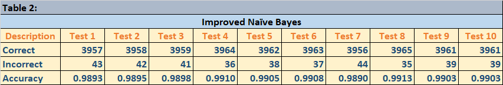

In table 2, we observed that model 8 has the highest accuracy with a level of 99.13%, so we use this model to work in our prediction for the test set and submit it on Kaggle. The result for the test set on Kaggle was 97.67% which tell us that our model overfitted the training set as on the test the acurracy went down.

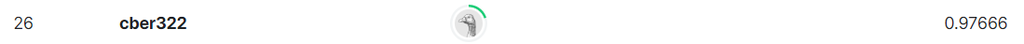

## Coding Part (appendix)

Refer to 'A2_code_cber322.ipynb' to see the code below.

```
# Standard Naive Bayes Classifier:

import pandas as pd

df_train = pd.read_csv('trg.csv', sep=',',)
df_train = df_train.rename(columns={'id': 'ID', 'class': 'CLASS','abstract': 'ABSTRACT'})

print(df_train.shape)
df_train.head()

df_train['CLASS'].value_counts(normalize=True)


# Split data set.
df_training = df_train

print(df_training.shape)


# cleaning
df_training['CLASS'].value_counts(normalize=True)

df_training.head(3)

df_training['ABSTRACT'] = df_training['ABSTRACT'].str.replace(
   '\W', ' ')
df_training['ABSTRACT'] = df_training['ABSTRACT'].str.lower()
df_training.head(3)

df_training['ABSTRACT'] = df_training['ABSTRACT'].str.split()
voca_list = []
for line in df_training['ABSTRACT']:
    for string in line:
        voca_list.append(string)

voca_list = list(set(voca_list))
len(voca_list)
string_counts = {string: [0] * len(df_training['ABSTRACT']) for string in voca_list}

for i, msg in enumerate(df_training['ABSTRACT']):
    for string in msg:
        string_counts[string][i] += 1
string_counts = pd.DataFrame(string_counts)
string_counts.head()
df_training_clean = pd.concat([df_training, string_counts], axis=1)
df_training.head()

# setting estimates
e_CLASS = df_training_clean[df_training_clean['CLASS'] == 'E']
b_CLASS = df_training_clean[df_training_clean['CLASS'] == 'B']
a_CLASS = df_training_clean[df_training_clean['CLASS'] == 'A']
v_CLASS = df_training_clean[df_training_clean['CLASS'] == 'V']


p_e_CLASS = len(e_CLASS) / len(df_training_clean)
p_b_CLASS= len(b_CLASS) / len(df_training_clean)
p_a_CLASS = len(a_CLASS) / len(df_training_clean)
p_v_CLASS = len(v_CLASS) / len(df_training_clean)

words_in_e_CLASS = e_CLASS['CLASS'].apply(len)
n_e = words_in_e_CLASS.sum()

words_in_b_CLASS = b_CLASS['CLASS'].apply(len)
n_b = words_in_b_CLASS.sum()

words_in_a_CLASS = a_CLASS['CLASS'].apply(len)
n_a = words_in_a_CLASS.sum()

words_in_v_CLASS = v_CLASS['CLASS'].apply(len)
n_v = words_in_v_CLASS.sum()

n_voca = len(voca_list)

Laplace_Smoothing = 1

estimates_e = {word:0 for word in voca_list}
estimates_b = {word:0 for word in voca_list}
estimates_a = {word:0 for word in voca_list}
estimates_v = {word:0 for word in voca_list}

# Calculate estimates
for string in voca_list:
    words_given_e = e_CLASS[string].sum()
    p_word_given_e = (words_given_e + Laplace_Smoothing) / (n_e + Laplace_Smoothing*n_voca)
    estimates_e[string] = p_word_given_e

    words_given_b = b_CLASS[string].sum()
    p_word_given_b = (words_given_b + Laplace_Smoothing) / (n_b + Laplace_Smoothing*n_voca)
    estimates_b[string] = p_word_given_b

    words_given_a = a_CLASS[string].sum()
    p_word_given_a = (words_given_a + Laplace_Smoothing) / (n_a + Laplace_Smoothing*n_voca)
    estimates_a[string] = p_word_given_a

    words_given_v = v_CLASS[string].sum()
    p_word_given_v = (words_given_v + Laplace_Smoothing) / (n_v + Laplace_Smoothing*n_voca)
    estimates_v[string] = p_word_given_v


# train the model.
import re
import math
def classification(abstract):

    abstract = re.sub('\W', ' ', abstract)
    abstract = abstract.lower().split()

    p_e_given_abstract = math.log(p_e_CLASS)
    p_b_given_abstract = math.log(p_b_CLASS)
    p_a_given_abstract = math.log(p_a_CLASS)
    p_v_given_abstract = math.log(p_v_CLASS)

    for string in abstract:
        if string in estimates_e:
            p_e_given_abstract += math.log(estimates_e[string])

        if string in estimates_b:
            p_b_given_abstract += math.log(estimatess_b[string])

        if string in estimates_a:
            p_a_given_abstract += math.log(estimates_a[string])

        if string in estimates_v:
            p_v_given_abstract += math.log(estimates_v[string])

    print('P(E|abstract):', p_e_given_abstract)
    print('P(B|abstract):', p_b_given_abstract)
    print('P(A|abstract):', p_a_given_abstract)
    print('P(V|abstract):', p_v_given_abstract)

    if p_e_given_abstract > p_b_given_abstract and p_e_given_abstract > p_a_given_abstract and p_e_given_abstract > p_v_given_abstract:
        print('CLASS: E')
    elif p_b_given_abstract > p_e_given_abstract and p_b_given_abstract > p_a_given_abstract and p_b_given_abstract > p_v_given_abstract:
        print('CLASS: B')
    elif p_a_given_abstract > p_e_given_abstract and p_a_given_abstract > p_b_given_abstract and p_a_given_abstract > p_v_given_abstract:
        print('CLASS: A')
    elif p_v_given_abstract > p_e_given_abstract and p_v_given_abstract > p_b_given_abstract and p_v_given_abstract > p_a_given_abstract:
        print('CLASS: V')
    else:
        print('classify')

# test the model.

import re
import math
def test_classification(abstract):

    abstract = re.sub('\W', ' ', abstract)
    abstract = abstract.lower().split()

    p_e_given_abstract = math.log(p_e_CLASS)
    p_b_given_abstract = math.log(p_b_CLASS)
    p_a_given_abstract = math.log(p_a_CLASS)
    p_v_given_abstract = math.log(p_v_CLASS)

    for string in abstract:
        if string in estimates_e:
            p_e_given_abstract += math.log(estimates_e[string])

        if string in estimates_b:
            p_b_given_abstract += math.log(estimates_b[string])

        if string in estimates_a:
            p_a_given_abstract += math.log(estimates_a[string])

        if string in estimates_v:
            p_v_given_abstract += math.log(estimates_v[string])

    if p_e_given_abstract > p_b_given_abstract and p_e_given_abstract > p_a_given_abstract and p_e_given_abstract > p_v_given_abstract:
        return ('E')
    elif p_b_given_abstract > p_e_given_abstract and p_b_given_abstract > p_a_given_abstract and p_b_given_abstract > p_v_given_abstract:
        return ('B')
    elif p_a_given_abstract > p_e_given_abstract and p_a_given_abstract > p_b_given_abstract and p_a_given_abstract > p_v_given_abstract:
        return ('A')
    elif p_v_given_abstract > p_e_given_abstract and p_v_given_abstract > p_b_given_abstract and p_v_given_abstract > p_a_given_abstract:
        return ('V')
    else:
        return 'classify'
```

```
df_test= pd.read_csv('trg.csv', sep=',')
df_test = df_test.rename(columns={'id': 'ID', 'class': 'CLASS','abstract': 'ABSTRACT'})

df_test['predicted'] = df_test['ABSTRACT'].apply(test_classification)
df_test.head()


count = 0
length = df_test.shape[0]

for line in df_test.iterrows():
    line = line[1]
    if line['CLASS'] == line['predicted']:
        count += 1

print('Standard Naive Bayes:')
print('TP + TN:', count)
print('FP + FN:', length - count)
print('Accuracy:', count/length)

    Standard Naive Bayes:
    TP + TN: 3535
    FP + FN: 465
    Accuracy: 0.88375



import pandas as pd
import numpy as np
import imblearn
import matplotlib.pyplot as plt
import seaborn as sns
from sklearn.feature_extraction.text import ENGLISH_STOP_WORDS

df_train = pd.read_csv('trg.csv', sep=',')
df_train = df_train.rename(columns={'id': 'ID', 'class': 'CLASS','abstract': 'ABSTRACT'})


df_train['CLASS'].value_counts()

# Improved Naive Bayes Classifier: we try the best out 10 random sampling model.
for i in range(1,11):

    # we use oversample to balanced the data set.
    max_size = df_train['CLASS'].value_counts().max()
    lst = [df_train]
    for class_index, group in df_train.groupby('CLASS'):
        lst.append(group.sample(max_size-len(group), replace=True))
    frame_new = pd.concat(lst)

    df_training = frame_new
    df_training['CLASS'].value_counts(normalize=True)
    df_training.head(3)

    # we clean the data set removing punctuation and transform in lowercase.
    df_training['ABSTRACT'] = df_training['ABSTRACT'].str.replace(
       '\W', ' ')
    df_training['ABSTRACT'] = df_training['ABSTRACT'].str.lower()
    df_training.head()

    # we create a vocabulary of words excluding digits and common words for both the vocabulary and the data set.
    text = df_training['ABSTRACT']
    voca_list = []
    new_train = []
    for line in text:
        words = [string for string in line.split() if string.lower() not in ENGLISH_STOP_WORDS and not string.isdigit()]
        new_text = " ".join(words)
        new_train.append(new_text)
        for string in new_text.split():
            voca_list.append(string)
    voca_list = list(set(voca_list))

    # we replace the new text into the dataset.
    df_new_text = pd.DataFrame(new_train, columns =['ABSTRACT'])
    df_training = df_training[['ID','CLASS']]
    df_training['ABSTRACT'] = df_new_text

    df_training['ABSTRACT'] = df_training['ABSTRACT'].str.split()
    word_counts = {string: [0] * len(df_training['ABSTRACT']) for string in voca_list}

    for i, msg in enumerate(df_training['ABSTRACT']):
        for string in msg:
            word_counts[string][i] += 1
    word_counts = pd.DataFrame(word_counts)
    df_training_clean = pd.concat([df_training.reset_index(drop=True), word_counts.reset_index(drop=True)], axis=1, sort=False)

    # Group the data by CLass
    e_CLASS = df_training_clean[df_training_clean['CLASS'] == 'E']
    b_CLASS = df_training_clean[df_training_clean['CLASS'] == 'B']
    a_CLASS = df_training_clean[df_training_clean['CLASS'] == 'A']
    v_CLASS = df_training_clean[df_training_clean['CLASS'] == 'V']

    # Calculating the probabilities.
    p_e_CLASS = len(e_CLASS) / len(df_training_clean)
    p_b_CLASS= len(b_CLASS) / len(df_training_clean)
    p_a_CLASS = len(a_CLASS) / len(df_training_clean)
    p_v_CLASS = len(v_CLASS) / len(df_training_clean)

    # counting each class.
    words_in_e_CLASS = e_CLASS['CLASS'].apply(len)
    n_e = words_in_e_CLASS.sum()
    words_in_b_CLASS = b_CLASS['CLASS'].apply(len)
    n_b = words_in_b_CLASS.sum()
    words_in_a_CLASS = a_CLASS['CLASS'].apply(len)
    n_a = words_in_a_CLASS.sum()
    words_in_v_CLASS = v_CLASS['CLASS'].apply(len)
    n_v = words_in_v_CLASS.sum()

    # number of word in the vocabulary
    n_voca = len(voca_list)

    # Laplace smoothing
    Laplace_Smoothing = 1

    # Initialize the estimates.
    estimates_e = {word:0 for word in voca_list}
    estimates_b = {word:0 for word in voca_list}
    estimates_a = {word:0 for word in voca_list}
    estimates_v = {word:0 for word in voca_list}

    # Calculating estimates.
    for string in voca_list:
        words_given_e = e_CLASS[string].sum()
        p_word_given_e = (words_given_e + Laplace_Smoothing) / (n_e + Laplace_Smoothing*n_voca)
        estimates_e[string] = p_word_given_e

        words_given_b = b_CLASS[string].sum()
        p_word_given_b = (words_given_b + Laplace_Smoothing) / (n_b + Laplace_Smoothing*n_voca)
        estimates_b[string] = p_word_given_b

        words_given_a = a_CLASS[string].sum()
        p_word_given_a = (words_given_a + Laplace_Smoothing) / (n_a + Laplace_Smoothing*n_voca)
        estimates_a[string] = p_word_given_a

        words_given_v = v_CLASS[string].sum()
        p_word_given_v = (words_given_v + Laplace_Smoothing) / (n_v + Laplace_Smoothing*n_voca)
        estimates_v[string] = p_word_given_v

    # function to calculate the probabilities.
    import re
    import math
    def test_classification(abstract):

        abstract = re.sub('\W', ' ', abstract)
        abstract = abstract.lower().split()

        p_e_given_abstract = math.log(p_e_CLASS)
        p_b_given_abstract = math.log(p_b_CLASS)
        p_a_given_abstract = math.log(p_a_CLASS)
        p_v_given_abstract = math.log(p_v_CLASS)

        for word in abstract:
            if word in estimates_e:
                p_e_given_abstract += math.log(estimates_e[word])

            if word in estimates_b:
                p_b_given_abstract += math.log(estimates_b[word])

            if word in estimates_a:
                p_a_given_abstract += math.log(estimates_a[word])

            if word in estimates_v:
                p_v_given_abstract += math.log(estimates_v[word])

        if p_e_given_abstract > p_b_given_abstract and p_e_given_abstract > p_a_given_abstract and p_e_given_abstract > p_v_given_abstract:
            return ('E')
        elif p_b_given_abstract > p_e_given_abstract and p_b_given_abstract > p_a_given_abstract and p_b_given_abstract > p_v_given_abstract:
            return ('B')
        elif p_a_given_abstract > p_e_given_abstract and p_a_given_abstract > p_b_given_abstract and p_a_given_abstract > p_v_given_abstract:
            return ('A')
        elif p_v_given_abstract > p_e_given_abstract and p_v_given_abstract > p_b_given_abstract and p_v_given_abstract > p_a_given_abstract:
            return ('V')
        else:
            return 'classify'
```

```
    # calculating the acurracy for the training set.

    df_test= pd.read_csv('trg.csv', sep=',',)
    df_test = df_test.rename(columns={'id': 'ID', 'class': 'CLASS','abstract': 'ABSTRACT'})
    df_test['predicted'] = df_test['ABSTRACT'].apply(test_classification)

    count = 0
    length = df_test.shape[0]

    for line in df_test.iterrows():
        line = line[1]
        if line['CLASS'] == line['predicted']:
            count += 1

    print('Test number'+ str(i))
    print('TP + TN:', count)
    print('FP + FN:', length - count)
    print('Accuracy:', count/length)

    # predicting values for the test set.

    df_test= pd.read_csv('tst.csv', sep=',',)
    df_test = df_test.rename(columns={'id': 'ID', 'class': 'CLASS','abstract': 'ABSTRACT'})
    df_test['predicted'] = df_test['ABSTRACT'].apply(test_classification)
    filename = 'prediction' + str(i) + '.csv'

    #exporting the prediction to a csv file.

    df_test.to_csv(filename)
```